# **Weekly Report 1: Tuesday January 2, 2024**

Welcome! This is my very first report of hopefully many to come on a little project I plan to work on for as long as possible (until I lose all my money 😅)

I call this project the Zhang Fund, although this really isn't a fund, but really just my family pooling some money together for me to manage (THANK YOU!!!)

Hopefully every week I'll be able to make a small report on some of the stuff I've been researching and reflect on my previous discussions!

## **The Portfolio**

As of today I have $30,000 to work with and currently have all of this sitting in an **Interactive Brokers Lite** Account accruing interest as I continue to do reaserch on picking stocks.

My current plan for the portfolio is to be 100% invested in equities (with some margin for cash) and approach stock selection with a more fundamental perspective to determine stocks that are undervalued by the market. Does a 21 year old college student really think he can beat the market? We'll just have to find out!

## **Interest Analysis**

```python
"""Importing Packages"""
import numpy as np
import pandas as pd
import seaborn as sns
from matplotlib import pyplot as plt

pd.options.display.float_format = '{:.0f}'.format
```

### **Interest Rate**

According to Interactive Brokers' Interest Rate Page, investors can earn interest on any outstanding cash balance, and the **annual** interest rate is determined by the following

$$ \text{Interest Rate} = \text{Benchmark Rate} - \text{Fixed Spread} $$

- The $\text{Fixed Spread}$ is determined by the type of brokerage account (Pro vs Lite)
- The $\text{Benchmark Rate}$ is determined by the **Effective Overnight Federal Funds Rate** (US Dollar Denominated Deposits)

Today we can express the variables as the following

```python
# fixed interest rate spread for the Interactive Brokers Lite Account
interactive_brokers_lite_interest_spread = .015

# Overnight Federal Funds Rate
benchmark_rate = .0533

interest_rate = benchmark_rate - interactive_brokers_lite_interest_spread

print(f"Interest Rate: {interest_rate * 100}%")
```

```
Interest Rate: 3.83%
```

I should note that I still have some confusion on what the term **Effective** means and how that effects the benchmark rate. For this report I will naively ignore this confusion in my analysis below and for future reports when I have a better understanding I will return to my analysis and make any necessary adjustments

### **Propotional Rate**

Unfortunately Interactive Brokers has some caveats to the stated interest rate we just calculated above! For accounts that have a $NAV < \$100,000$ the interest rate we recieve is the proportion of the $NAV$ of the account with $\$100,000$

This means that the interest rate we actually recieve is the following

$$ \text{Proportional Rate} = \text{Interest Rate} * NAV\text{ Proportion}$$

In our case

$$ \text{Proportional Rate} = 3.83\% * (\frac{\$30,000}{\$100,000}) = 3.83\% * .3 = 1.149\%$$

```python
net_asset_value = 30000.00
benchmark_net_asset_value = 100000.00

proportion = net_asset_value/benchmark_net_asset_value
proportional_rate = interest_rate * proportion

print(f"Proportional Rate: {proportional_rate*100}%")
```

```
Proportional Rate: 1.149%
```

### **Blended Rate**

The final caveat here is that the first $\$10,000$ of outstanding cash doesn't actually accrue any interest. Interactive Brokers have coined a term called the **Blended Rate** which incorporates the non-accrual of the $\$10,000$ that is the actual interest we recieve

$$\text{Blended Rate} = \frac{\text{Proportional Interest Rate} * (\text{Cash Balance} - \$10,000)}{\text{Cash Balance}}$$

In our case

$$\text{Blended Rate} = \frac{1.149\% * (\$30,000 - \$10,000)}{\$30,000} = 0.766\%$$

Sadly this is more than $3\%$ **less than** the **original interest rate** before the caveats. It may be smarter to have this money invested in TBills instead of earning a dismal $0.766\%$ per year

```python
cash_balance = 30000.00
cash_deduction = 10000.00
cash_balance_after_deduction = cash_balance - cash_deduction

blended_rate = (proportional_rate * cash_balance_after_deduction) / cash_balance
print(f"Blended Rate: {blended_rate * 100}%")
```

```
Blended Rate: 0.766%
```

## **Interest Accural and Payment**

source: https://www.interactivebrokers.com/en/pricing/pricing-calculations-int.php

### **Simple Interest**

- Monthly: $19.15
- Annualy: $229.80
- 10 Year: $2298.00

```python
def calculate_simple_interest(annual_interest_rate, principal, number_of_years):
    principal_and_interest = principal * (1 + (annual_interest_rate) * (number_of_years))
    just_principal = principal_and_interest - principal

    return [principal_and_interest, just_principal]

months_per_year = 12
frequency = 1/months_per_year

monthly_simple_interest = cash_balance * (blended_rate * frequency)
annual_simple_interest = monthly_simple_interest * months_per_year
ten_year_simple_interest = annual_simple_interest * 10

print(f"Monthly Simple Interest: {monthly_simple_interest}")
print(f"Annual Simple Interest: {annual_simple_interest}")
print(f"10 Year Simple Interest: {ten_year_simple_interest}")
```

```
Monthly Simple Interest: 19.15
Annual Simple Interest: 229.79999999999998
10 Year Simple Interest: 2298.0
```

### Compound Interest

With the same assumptions as above with compounding effects (leaving the paid interest in the brokerage account) every month then we will have the following payout:

```python
# utility function to calculate compound interest based on 4 parameters, returns an array with the principal + interest and just interest
def calculate_compound_interest(annual_interest_rate, principal, annual_compounding_frequency, number_of_years):
    principal_and_interest = principal * (1 + annual_interest_rate/annual_compounding_frequency) ** (annual_compounding_frequency * number_of_years)
    just_interest = principal_and_interest - principal

    return [principal_and_interest, just_interest]

one_year_compound_interest = calculate_compound_interest(blended_rate, cash_balance, 12, 1)
five_year_compound_interest = calculate_compound_interest(blended_rate, cash_balance, 12, 5)
ten_year_compound_interest = calculate_compound_interest(blended_rate, cash_balance, 12, 10)

print(f"1 Year Compound Interest: {one_year_compound_interest[1]}")
print(f"5 Year Compound Interest: {five_year_compound_interest[1]}")
print(f"10 Year Compound Interest: {ten_year_compound_interest[1]}")
```

```
1 Year Compound Interest: 230.60850863684027
5 Year Compound Interest: 1170.9060938718649
10 Year Compound Interest: 2387.512890432601
```

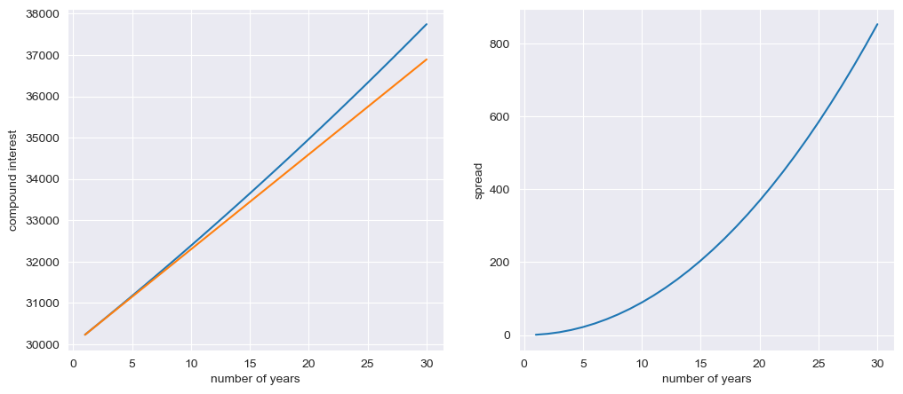

```python
"""Plotting Both Compound and Simple Interest"""
number_of_years = np.arange(1, 31)
years = np.arange(2023, 2053)

simple_interest = calculate_simple_interest(blended_rate, cash_balance, number_of_years)
compound_interest = calculate_compound_interest(blended_rate, cash_balance, months_per_year, number_of_years)

# stick in dataframe
interest_df = pd.DataFrame({"number of years": number_of_years, "years": years,"simple interest": simple_interest[0],"compound interest": compound_interest[0]})
interest_df["spread"] = interest_df["compound interest"] - interest_df["simple interest"]

sns.set_style("darkgrid")
fig, axs = plt.subplots(1,2, figsize=(12,5))
sns.lineplot(data=interest_df, x="number of years", y="compound interest", ax=axs[0])
sns.lineplot(data=interest_df, x="number of years", y="simple interest", ax=axs[0])

sns.lineplot(data=interest_df, x="number of years", y="spread", ax=axs[1])
```

19.20 * 12

```python
19.20 * 12
```

```
230.39999999999998
```

```python
19.20 / 20000
```

```
0.0009599999999999999
```

```python
.0383 * .3
```

```
0.01149
```